# Course Project 1 Reproducible Research

## Author: Francisco Ramirez

First, we read the data.

```r
library(data.table)
data<-read.csv("activity.csv",stringsAsFactors = TRUE)
#we convert string to date
data<-data.table(data)
```

We converted the data frame with the information to a data table to ease the analysis. So, we need to do numerous things:

1. What is mean total number of steps taken per day?
- Calculate the total number of steps taken per day.

```r
steps_per_day<-data[,sum(steps,na.rm=TRUE),by=as.factor(data$date)]
names(steps_per_day)<-c("date","spd")
head(steps_per_day)
```

```
##          date   spd
## 1: 2012-10-01     0
## 2: 2012-10-02   126
## 3: 2012-10-03 11352
## 4: 2012-10-04 12116
## 5: 2012-10-05 13294
## 6: 2012-10-06 15420
```

- Make a histogram of the total number of steps taken each day

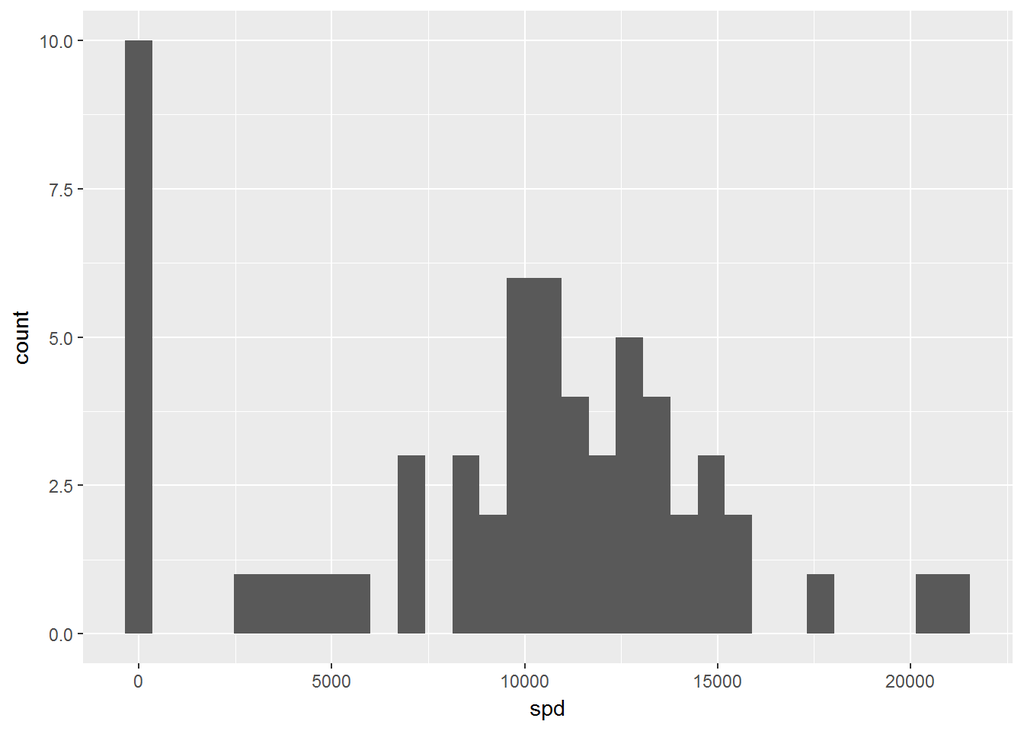

```r
library(ggplot2)
bin<-(range(steps_per_day$spd)[2]-range(steps_per_day$spd)[1])/30
qplot(spd,data=steps_per_day,binwidth=bin)
```

- Calculate and report the mean and median of the total number of steps taken per day

```r
report<-c(mean(steps_per_day$spd),median(steps_per_day$spd))
names(report)<-c("mean","median")
report
```

```
##     mean   median
##  9354.23 10395.00
```

2. What is the average daily activity pattern?
- Make a time series plot (i.e. type = “l”) of the 5-minute interval (x-axis) and the average number of steps taken, averaged across all days (y-axis).

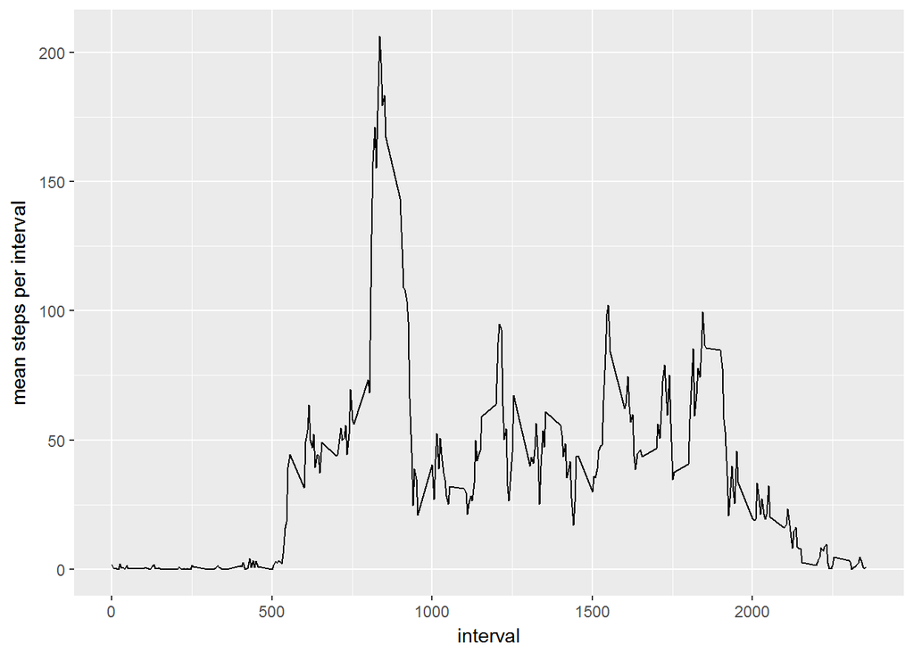

```r
steps_per_int<-data[,mean(steps,na.rm=TRUE),by=as.factor(data$interval)]
names(steps_per_int)<-c("interval","mean_steps")
steps_per_int$interval<-unique(data$interval)
ggplot(data=steps_per_int,aes(x=interval,y=mean_steps))+geom_line()+labs(x="interval",y="mean steps per interval")
```

- Which 5-minute interval, on average across all the days in the dataset, contains the maximum number of steps?

```r
steps_per_int[mean_steps==max(mean_steps),]
```

```
##    interval mean_steps
## 1:      835   206.1698
```

We see that the interval corresponding to 835 has the maximum number of steps on average.

3. Imputing missing values
- Calculate and report the total number of missing values in the dataset (i.e. the total number of rows with NAs)

```r
nrow(data)-sum(complete.cases(data))
```

```
## [1] 2304
```

- Devise a strategy for filling in all of the missing values in the dataset. The strategy does not need to be sophisticated. For example, you could use the mean/median for that day, or the mean for that 5-minute interval, etc.